# Method for computerized standardization of arbitrary urinary output charting for the diagnosis of AKI: A derivation-validation proof of concept study using two multicenter databases

Ariel Avraham Hasidim, Matthew Adam Klein, Itamar Ben Shitrit, Karny Ilan, Sharon Einav, Lior Fuchs

April 7th, 2024

This is a full reproduction for the results of the validation cohort (AUMCdb).

**For more details see:**

- Full article at Scientific Data: doi
- GitHub repository

### Citation

# Population and Study’s Sample

**Total I/M-CU stays in aumc:**

```r
print("Medium and intensive care:")
```

```
## [1] "Medium and intensive care:"
```

```r
dbGetQuery(con, "SELECT count(*) FROM `original.admissions`")
```

```
## # A tibble: 1 × 1
##     f0_
##   <int>
## 1 23106
```

```r
print("Intensive care only:")
```

```
## [1] "Intensive care only:"
```

```r
dbGetQuery(con, "SELECT count(*) FROM `original.admissions` WHERE lower(location) != 'mc'")
```

```
## # A tibble: 1 × 1
##     f0_
##   <int>
## 1 18386
```

**ICU stays with UO records (eligible):**

```r
print("Raw UO per service type:")
```

```
## [1] "Raw UO per service type:"
```

```r
table(raw_uo$SERVICE)
```

```
##
##      IC   IC&MC      MC   MC&IC
## 1189758  374109  106537    9666
```

```r
print("Total eligible ICU admissions:")
```

```
## [1] "Total eligible ICU admissions:"
```

```r
raw_uo %>% filter(SERVICE != "MC") %>%
  {n_distinct(.$STAY_ID)}
```

```
## [1] 18147
```

**Patients with UO records:**

```r
raw_uo %>% filter(SERVICE != "MC") %>%
  {n_distinct(.$SUBJECT_ID)}
```

```
## [1] 16344
```

**Count all UO records (before exclusions):**

```r
all_rows_count <- nrow(raw_uo %>% filter(SERVICE != "MC"))
all_rows_count
```

```
## [1] 1573533
```

## Figure for Raw UO Records Data

Frequency of urine output charting by source

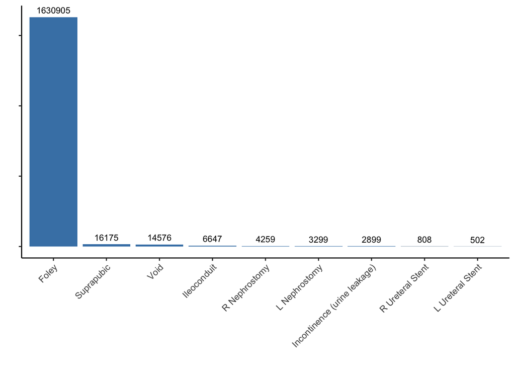

```r
bS3a <- raw_uo %>%
  mutate(
    LABEL = case_when(
      LABEL == "GU Irrigant/Urine Volume Out" ~ "GU Irrig. Out",
      LABEL == "GU Irrigant Volume In" ~ "GU Irrig. In",
      .default = LABEL
    )
  ) %>% count(LABEL, sort = TRUE) %>%
   ggplot(aes(x=reorder(LABEL, -n), y=n)) +
   geom_bar(stat="identity") +
   xlab("") +
   ylab("") +
   geom_bar(stat="identity", fill="steelblue") +
   geom_text(aes(label=n), vjust=-0.6, color="black", size=3) +
   theme_classic() +
   theme(axis.text.y=element_blank()) +
   theme(axis.text.x = element_text(angle = 45, hjust = 1)) +
       theme(
         plot.title = element_text(color = "#0099F8", size = 16, face = "bold"),
         plot.subtitle = element_text(size = 10, face = "bold"),
         plot.caption = element_text(face = "italic")
       )

bS3a
```

## Duplication Analysis

### Check for Distinctiveness

First, we are basing distinctive rows in the raw UO data.

**Count distinct raw rows:**

```r
distinct_time_item_patient_rows_count <- raw_uo %>%
  select(-VALUE,
         -SERVICE,
         -LABEL) %>%
  n_distinct()

distinct_time_item_patient_rows_count
```

```
## [1] 1680070
```

Conclusion: the original raw query does not have duplicates (all rows are distinct by all columns)

### Check for Simultaneous Charting

```r
raw_uo_excluions_duplicates$same_value <- as.factor(raw_uo_excluions_duplicates$same_value)
raw_uo_excluions_duplicates$label <- as.factor(raw_uo_excluions_duplicates$label)
raw_uo_excluions_duplicates$label <- factor(raw_uo_excluions_duplicates$label, levels = as.factor(names(sort(table(raw_uo_excluions_duplicates$label),
                                  decreasing = TRUE))))

S1_a <- raw_uo_excluions_duplicates %>%
  select(same_value, label) %>%
  tbl_summary(by = same_value)

S1_a
```

| **Characteristic** | **Different volume**, N = 6,180<sup>1</sup> | **Equal volume**, N = 573<sup>1</sup> |
| --- | --- | --- |
| label |  |  |
| Foley,R Nephrostomy | 1,200 (19%) | 189 (33%) |
| Foley,L Nephrostomy | 967 (16%) | 102 (18%) |
| Foley,L Nephrostomy,R Nephrostomy | 942 (15%) | 40 (7.0%) |
| Foley,Suprapubic | 701 (11%) | 37 (6.5%) |
| L Nephrostomy,R Nephrostomy | 421 (6.8%) | 50 (8.7%) |
| Suprapubic,R Nephrostomy | 331 (5.4%) | 28 (4.9%) |
| Foley,Suprapubic,L Nephrostomy,R Nephrostomy,L Ureteral Stent,R Ureteral Stent | 339 (5.5%) | 0 (0%) |
| Foley,Void | 182 (2.9%) | 10 (1.7%) |
| Foley,Ileoconduit | 159 (2.6%) | 21 (3.7%) |
| Foley,Incontinence (urine leakage) | 159 (2.6%) | 17 (3.0%) |
| Suprapubic,Ileoconduit | 131 (2.1%) | 18 (3.1%) |
| Ileoconduit,L Nephrostomy,R Nephrostomy | 93 (1.5%) | 2 (0.3%) |
| Foley,Suprapubic,L Nephrostomy,R Nephrostomy | 61 (1.0%) | 3 (0.5%) |
| Foley,Suprapubic,Ileoconduit | 61 (1.0%) | 0 (0%) |
| Suprapubic,Void | 59 (1.0%) | 1 (0.2%) |
| Foley,L Ureteral Stent,R Ureteral Stent | 57 (0.9%) | 1 (0.2%) |
| Void,Incontinence (urine leakage) | 38 (0.6%) | 7 (1.2%) |
| Void,L Nephrostomy | 35 (0.6%) | 4 (0.7%) |
| Ileoconduit,R Ureteral Stent | 24 (0.4%) | 11 (1.9%) |
| Ileoconduit,R Nephrostomy | 32 (0.5%) | 0 (0%) |
| Incontinence (urine leakage),Ileoconduit | 29 (0.5%) | 1 (0.2%) |
| Foley,L Ureteral Stent | 25 (0.4%) | 3 (0.5%) |
| L Ureteral Stent,R Ureteral Stent | 7 (0.1%) | 15 (2.6%) |
| Ileoconduit,L Nephrostomy,R Nephrostomy,R Ureteral Stent | 16 (0.3%) | 0 (0%) |
| Suprapubic,Incontinence (urine leakage) | 12 (0.2%) | 3 (0.5%) |
| Suprapubic,R Ureteral Stent | 12 (0.2%) | 1 (0.2%) |
| Void,R Nephrostomy | 11 (0.2%) | 1 (0.2%) |
| L Nephrostomy,R Nephrostomy,R Ureteral Stent | 10 (0.2%) | 0 (0%) |
| Suprapubic,L Nephrostomy | 7 (0.1%) | 2 (0.3%) |
| Foley,Ileoconduit,L Nephrostomy | 8 (0.1%) | 0 (0%) |
| Foley,L Nephrostomy,R Nephrostomy,L Ureteral Stent,R Ureteral Stent | 6 (<0.1%) | 0 (0%) |
| Foley,Suprapubic,L Nephrostomy | 5 (<0.1%) | 0 (0%) |
| Ileoconduit,L Nephrostomy | 4 (<0.1%) | 1 (0.2%) |
| Incontinence (urine leakage),L Nephrostomy | 5 (<0.1%) | 0 (0%) |
| L Nephrostomy,R Nephrostomy,L Ureteral Stent,R Ureteral Stent | 5 (<0.1%) | 0 (0%) |
| Suprapubic,L Nephrostomy,R Nephrostomy | 4 (<0.1%) | 1 (0.2%) |
| Ileoconduit,R Nephrostomy,R Ureteral Stent | 4 (<0.1%) | 0 (0%) |
| Suprapubic,L Nephrostomy,R Nephrostomy,L Ureteral Stent,R Ureteral Stent | 3 (<0.1%) | 0 (0%) |
| Void,Ileoconduit | 2 (<0.1%) | 1 (0.2%) |
| Foley,Suprapubic,Incontinence (urine leakage) | 2 (<0.1%) | 0 (0%) |
| Foley,Suprapubic,R Nephrostomy,L Ureteral Stent,R Ureteral Stent | 2 (<0.1%) | 0 (0%) |
| Foley,Void,Incontinence (urine leakage) | 2 (<0.1%) | 0 (0%) |
| Foley,Suprapubic,L Nephrostomy,R Nephrostomy,L Ureteral Stent | 1 (<0.1%) | 0 (0%) |
| Foley,Suprapubic,L Nephrostomy,R Nephrostomy,R Ureteral Stent | 1 (<0.1%) | 0 (0%) |
| Foley,Suprapubic,R Nephrostomy,R Ureteral Stent | 1 (<0.1%) | 0 (0%) |
| Foley,Suprapubic,Void | 1 (<0.1%) | 0 (0%) |
| Foley,Void,Ileoconduit | 0 (0%) | 1 (0.2%) |
| Ileoconduit,L Nephrostomy,R Ureteral Stent | 1 (<0.1%) | 0 (0%) |
| R Nephrostomy,R Ureteral Stent | 0 (0%) | 1 (0.2%) |
| Suprapubic,Incontinence (urine leakage),Ileoconduit | 0 (0%) | 1 (0.2%) |
| Suprapubic,Void,Incontinence (urine leakage) | 1 (<0.1%) | 0 (0%) |
| Void,L Nephrostomy,R Nephrostomy | 1 (<0.1%) | 0 (0%) |

<sup>1</sup> n (%)

Show full SQL query —–>

```sql
WITH aa AS (
        SELECT
            STAY_ID,
            CHARTTIME
        FROM
            `aumc_uo_and_aki.a_urine_output_raw` uo
        GROUP BY
            STAY_ID,
            CHARTTIME
    ),
    ab AS (
        SELECT
            a.*,
            b.ITEMID,
            b.VALUE,
            b.LABEL
        FROM
            aa a
            LEFT JOIN `aumc_uo_and_aki.a_urine_output_raw` b ON b.STAY_ID = a.STAY_ID
            AND b.CHARTTIME = a.CHARTTIME
        ORDER BY
            STAY_ID,
            CHARTTIME,
            ITEMID
    ),
    ac AS (
        SELECT
            STAY_ID,
            CHARTTIME,
            STRING_AGG(label) label,
            COUNT(STAY_ID) COUNT,
            IF(
                MIN(VALUE) = MAX(VALUE),
                "Equal volume",
                "Different volume"
            ) AS same_value
        FROM
            ab
        GROUP BY
            STAY_ID,
            CHARTTIME
    ),
    ad AS (
        SELECT
            COUNT(CHARTTIME) COUNT,
            label,
            same_value
        FROM
            ac
        WHERE
            COUNT > 1
        GROUP BY
            label,
            same_value
    )
SELECT
    *
FROM
    ac
WHERE
    COUNT > 1
```

In conclusion, most of the records have different values, and thus human error in duplicate record-keeping is not likely.

## Exclusion

Used for *Figure 2. Overview of study’s process.*

**ICU type exclusion:**

```r
dbGetQuery(con, statement = read_file('sql/service_type_exclusion.sql'))
```

```
## # A tibble: 1 × 2
##   icu_stays UO_records
##       <int>      <int>
## 1      4641     106537
```

Show full SQL query —–>

```sql
SELECT
    COUNT(DISTINCT STAY_ID) icu_stays,
    COUNT(STAY_ID) UO_records
FROM
    `aumc_uo_and_aki.a_urine_output_raw`
WHERE
    lower(SERVICE) = "mc"
```

**Uretral stent exclusion:**

```r
dbGetQuery(con, statement = read_file('sql/ure_stent_exclusion.sql'))
```

```
## # A tibble: 1 × 2
##   icu_stays UO_records
##       <int>      <int>
## 1        10       3804
```

Show full SQL query —–>

```sql
SELECT
    COUNT(DISTINCT STAY_ID) icu_stays,
    COUNT(STAY_ID) UO_records
FROM
    `aumc_uo_and_aki.a_urine_output_raw`
WHERE
    STAY_ID IN (
        SELECT
            admissionid AS STAY_ID
        FROM
            `original.numericitems`
        WHERE
            ITEMID IN (19921, 19922) -- Urethral stent
        GROUP BY
            admissionid
    )
    AND lower(SERVICE) != "mc"
```

**Urine incontinence exclusion:**

```r
dbGetQuery(con, statement = read_file('sql/Incontinence_exclusion.sql'))
```

```
## # A tibble: 1 × 2
##   icu_stays UO_records
##       <int>      <int>
## 1       250      62136
```

Show full SQL query —–>

```sql
SELECT
    COUNT(DISTINCT STAY_ID) icu_stays,
    COUNT(STAY_ID) UO_records
FROM
    `aumc_uo_and_aki.a_urine_output_raw`
WHERE
    STAY_ID IN (
        SELECT
            admissionid AS STAY_ID
        FROM
            `original.numericitems`
        WHERE
            ITEMID IN (8800) -- Incontinence (Urine leakage)
        GROUP BY
            admissionid
    )
    AND STAY_ID NOT IN (
        SELECT
            admissionid AS STAY_ID
        FROM
            `original.numericitems`
        WHERE
            ITEMID IN (19921, 19922) -- Urethral stent
        GROUP BY
            admissionid
    )
    AND lower(SERVICE) != "mc"
```

**Not passing sanity check:**

```r
dbGetQuery(con, statement = read_file('sql/sanity.sql'))
```

```
## # A tibble: 1 × 1
##   UO_records
##        <int>
## 1          4
```

Show full SQL query —–>

```sql
SELECT
  COUNT(STAY_ID) UO_records
FROM
  `aumc_uo_and_aki.a_urine_output_raw`
WHERE
  STAY_ID NOT IN (
    SELECT
      admissionid AS STAY_ID
    FROM
      `original.numericitems`
    WHERE
      ITEMID IN (8800) -- Incontinence (Urine leakage)
    GROUP BY
      admissionid
  )
  AND STAY_ID NOT IN (
    SELECT
      admissionid AS STAY_ID
    FROM
      `original.numericitems`
    WHERE
      ITEMID IN (19921, 19922) -- Urethral stent
    GROUP BY
      admissionid
  )
  AND LOWER(SERVICE) != "mc"
  AND (
    VALUE > 5000
    OR VALUE < 0
  )
```

**Total raw urine output after exclusion (“eligible records, before collection time”):**

```r
nrow(raw_uo_eligible)
```

```
## [1] 1507589
```

Show full SQL query —–>

```sql
SELECT
  *
FROM
  `aumc_uo_and_aki.a_urine_output_raw`
WHERE
  STAY_ID NOT IN (
    SELECT
      admissionid AS STAY_ID
    FROM
      `original.numericitems`
    WHERE
      ITEMID IN (19922, 19921, 8800) -- Urethral stent, Urine Incontinence
    GROUP BY
      admissionid
  )
  AND NOT (
    VALUE > 5000
    OR VALUE < 0
  )
  AND lower(SERVICE) != "mc"
```

**Total icu stays after exclusion (“eligible icu admissions, before collection time”):**

```r
n_distinct(raw_uo_eligible$STAY_ID)
```

```
## [1] 17887
```

**Exclusion of first volume in each compartment per ICU stay:**

```r
uo_rate_including_null_collection_period %>%
  filter(STAY_ID %in% raw_uo_eligible$STAY_ID) %>%
  filter(is.na(TIME_INTERVAL)) %>%
  nrow()
```

```
## [1] 18062
```

**UO records with time intervals:**

```r
uo_rate_including_null_collection_period %>%
  filter(STAY_ID %in% raw_uo_eligible$STAY_ID) %>%
  drop_na(TIME_INTERVAL) %>%
  nrow()
```

```
## [1] 1489527
```

**Count UO records by anatomical compartment:**

```r
uo_rate %>%
  mutate(agg_group = case_when(SOURCE == "Foley" |
                                 SOURCE == "Condom Cath" |
                                 SOURCE == "Straight Cath" |
                                 SOURCE == "Suprapubic" |
                                 SOURCE == "Void" ~ "Urinary bladder",
                               TRUE ~ SOURCE)
  ) %>%
           group_by(agg_group) %>%
   dplyr::summarise(N = n()
  )
```

```
## # A tibble: 4 × 2
##   agg_group             N
##   <chr>             <int>
## 1 Ileoconduit        4749
## 2 L Nephrostomy      2404
## 3 R Nephrostomy      3423
## 4 Urinary bladder 1478951
```

**ICU stays with UO records with time intervals:**

```r
print("all ICU stays:")
```

```
## [1] "all ICU stays:"
```

```r
uo_rate_including_null_collection_period %>%
  {n_distinct(.$STAY_ID)}
```

```
## [1] 17887
```

```r
print("ICU stays with time intervals:")
```

```
## [1] "ICU stays with time intervals:"
```

```r
uo_rate_including_null_collection_period %>%
                     drop_na(TIME_INTERVAL) %>%
  {n_distinct(.$STAY_ID)}
```

```
## [1] 17736
```

```r
print("ICU stays with UO records that does not  have time interval (no previous UO record in the same compartment:")
```

```
## [1] "ICU stays with UO records that does not  have time interval (no previous UO record in the same compartment:"
```

```r
uo_rate_including_null_collection_period %>%
                     filter(is.na(TIME_INTERVAL)) %>%
  {n_distinct(.$STAY_ID)}
```

```
## [1] 17887
```

```r
print("ICU stays dropped due to no UO records with time intervalst (no previous UO record in the same compartment:")
```

```
## [1] "ICU stays dropped due to no UO records with time intervalst (no previous UO record in the same compartment:"
```

```r
(uo_rate_including_null_collection_period %>%
                     filter(is.na(TIME_INTERVAL))) %>%
  filter(!(STAY_ID %in% (uo_rate_including_null_collection_period %>%
                     drop_na(TIME_INTERVAL))$STAY_ID)) %>%
  {n_distinct(.$STAY_ID)}
```

```
## [1] 151
```

**Count total ICU days of UO monitoring for icu stays with time intervals:**

```r
hourly_uo %>%
  filter(STAY_ID %in%
           (uo_rate_including_null_collection_period %>%
                     drop_na(TIME_INTERVAL))$STAY_ID) %>%
  nrow() / 24
```

```
## [1] 89959.58
```

**Hours of UO monitoring:**

```r
print("Eligible hours of UO monitoring:")
```

```
## [1] "Eligible hours of UO monitoring:"
```

```r
hourly_uo %>%
  filter(STAY_ID %in% raw_uo_eligible$STAY_ID) %>%
  nrow()
```

```
## [1] 2159186
```

```r
print("Valid hourly-adjusted UO monitoring hours:")
```

```
## [1] "Valid hourly-adjusted UO monitoring hours:"
```

```r
hourly_uo %>%
  filter(STAY_ID %in% raw_uo_eligible$STAY_ID) %>%
  drop_na(HOURLY_VALID_WEIGHTED_MEAN_RATE) %>%
  nrow()
```

```
## [1] 2065999
```

```r
print("ICU stays with valid hourly-adjusted UO monitoring hours:")
```

```
## [1] "ICU stays with valid hourly-adjusted UO monitoring hours:"
```

```r
hourly_uo %>%
  filter(STAY_ID %in% raw_uo_eligible$STAY_ID) %>%
  drop_na(HOURLY_VALID_WEIGHTED_MEAN_RATE) %>%
  {n_distinct(.$STAY_ID)}
```

```
## [1] 17708
```

**Proportion of valid hours covered out of included hours of uo monitoring:**

```r
hourly_uo %>%
  filter(STAY_ID %in% raw_uo_eligible$STAY_ID) %>%
  drop_na(HOURLY_VALID_WEIGHTED_MEAN_RATE) %>%
  nrow() / hourly_uo %>%
  filter(STAY_ID %in% raw_uo_eligible$STAY_ID) %>%
  nrow()
```

```
## [1] 0.9568416
```

**Hourly-adjusted UO with admission weights:**

```r
print("ICU stays with admission weight and valid hourly-adjusted UO:")
```

```
## [1] "ICU stays with admission weight and valid hourly-adjusted UO:"
```

```r
hourly_uo %>%
  filter(STAY_ID %in% raw_uo_eligible$STAY_ID) %>%
  drop_na(HOURLY_VALID_WEIGHTED_MEAN_RATE, WEIGHT_ADMIT) %>%
  {n_distinct(.$STAY_ID)}
```

```
## [1] 17117
```

```r
print("Valid hourly-adjusted UO monitoring hours with admission weights:")
```

```
## [1] "Valid hourly-adjusted UO monitoring hours with admission weights:"
```

```r
hourly_uo %>%
  filter(STAY_ID %in% raw_uo_eligible$STAY_ID) %>%
  drop_na(HOURLY_VALID_WEIGHTED_MEAN_RATE, WEIGHT_ADMIT) %>%
  nrow()
```

```
## [1] 1993167
```

**ICU stays with calculated KDIGO-UO staging (at least six consecutive hours with valid charting of hourly-adjusted UO)**

```r
print("number of ICU stays with valid KDIGO-UO staging")
```

```
## [1] "number of ICU stays with valid KDIGO-UO staging"
```

```r
kdigo_uo_stage %>%
  filter(stay_id %in% raw_uo_eligible$STAY_ID) %>%
  {n_distinct(.$stay_id)}
```

```
## [1] 16826
```

```r
print("number of included hours with valid KDIGO-UO staging")
```

```
## [1] "number of included hours with valid KDIGO-UO staging"
```

```r
kdigo_uo_stage %>%
  filter(stay_id %in% raw_uo_eligible$STAY_ID) %>%
  nrow()
```

```
## [1] 1887199
```

**eligible first ICU admission to each patient for AKI analysis**

```r
first_icu_stay <-
  dbGetQuery(
    con,
    "SELECT patientid, admissionid FIRST_STAY_ID_IN_PATIENT FROM `original.admissions`
where admissioncount = 1"
  )

print("number of first ICU stays with valid KDIGO-UO staging")
```

```
## [1] "number of first ICU stays with valid KDIGO-UO staging"
```

```r
kdigo_uo_stage %>%
  filter(stay_id %in% first_icu_stay$FIRST_STAY_ID_IN_PATIENT
         & stay_id %in% raw_uo_eligible$STAY_ID) %>%
  {n_distinct(.$stay_id)}
```

```
## [1] 14894
```

```r
print("number of valid hourly KDIGO-UO staging in first ICU stays")
```

```
## [1] "number of valid hourly KDIGO-UO staging in first ICU stays"
```

```r
kdigo_uo_stage %>%
  filter(stay_id %in% first_icu_stay$FIRST_STAY_ID_IN_PATIENT
         & stay_id %in% raw_uo_eligible$STAY_ID) %>%
  nrow()
```

```
## [1] 1490408
```

**included ICU admissions for AKI analysis**

```r
print("number of first ICU stays (after exclusion criteria) with valid KDIGO-UO staging for the first 24-hours ins ICU stay")
```

```
## [1] "number of first ICU stays (after exclusion criteria) with valid KDIGO-UO staging for the first 24-hours ins ICU stay"
```

```r
kdigo_uo_stage %>%
  filter(stay_id %in% aki_epi$STAY_ID) %>%
  {n_distinct(.$stay_id)}
```

```
## [1] 14884
```

```r
print("number of valid hourly KDIGO-UO for those stays")
```

```
## [1] "number of valid hourly KDIGO-UO for those stays"
```

```r
kdigo_uo_stage %>%
  filter(stay_id %in% aki_epi$STAY_ID) %>%
  nrow()
```

```
## [1] 1488928
```

## Inclusion/Exclusion Flowchart

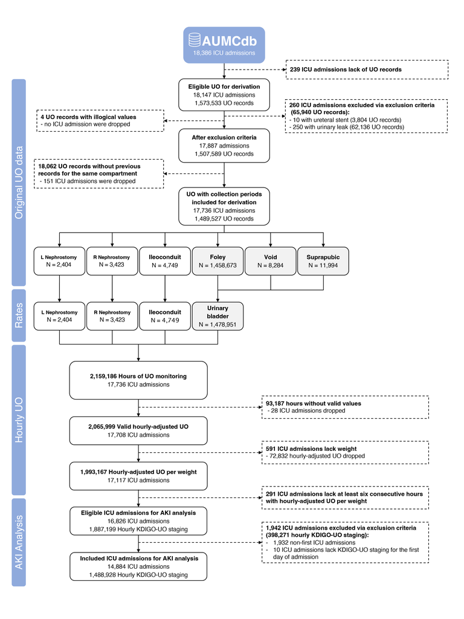

```r
knitr::include_graphics("flow chart.png")
```

## Table 1 - Patient’s characteristics

```r
table_1$SERVICE <- as.factor(table_1$SERVICE)
table_1$admission_age <- as.numeric(table_1$admission_age)
table_1$weight_admit <- as.numeric(table_1$weight_admit)
table_1$height_first <- as.numeric(table_1$height_first)

uo_for_table1 <- uo_rate_including_null_collection_period %>%
  drop_na(TIME_INTERVAL) %>%
  group_by(STAY_ID) %>%
  summarise(
    count = n(),
    volumes = mean(VALUE, na.rm = TRUE),
    collection_times = mean(TIME_INTERVAL, na.rm = TRUE),
    rates = mean(HOURLY_RATE, na.rm = TRUE),
    validity = mean(if_else(VALIDITY == TRUE, 1, 0)),
    ml_kg_hr = mean(HOURLY_RATE / WEIGHT_ADMIT, na.rm = TRUE)
  )

t1a <- table_1 %>%
  select(
    admission_age,
    gender,
    weight_admit,
    creat_first,
    icu_days,
    rrt_binary,
    hospital_expire_flag
  ) %>%
  tbl_summary(
    type = list(
      c(hospital_expire_flag,
        rrt_binary) ~ "dichotomous",
      c(admission_age,
        weight_admit,
        creat_first) ~ "continuous"
    ),
    statistic = c(admission_age,
                  weight_admit,
                  creat_first) ~ "{mean} ({sd})",
    digits = list(icu_days ~ 1),
    missing = "no",
    label = list(
      admission_age ~ "Age at Hospital Admission, years",
      gender ~ "Gender",
      creat_first ~ "First Creatinine, mg/dL",
      weight_admit ~ "Weight at ICU Admission, kg",
      icu_days ~ "Time in ICU, days",
      rrt_binary ~ "Renal replacement therapy",
      hospital_expire_flag ~ "Mortality"
    )
  ) %>%
  add_n()

display_prec <- function(x)
  mean(x) * 100

t1b <- uo_for_table1 %>%
  select(count,
         volumes,
         validity,
         collection_times,
         rates,
         ml_kg_hr) %>%
  tbl_summary(
    type = list(
      c(volumes,
        collection_times,
        rates,
        ml_kg_hr,
        validity) ~ "continuous"
    ),
    statistic = list(
      c(volumes,
        collection_times,
        rates,
        ml_kg_hr) ~ "{mean} ({sd})",
      validity ~ "{display_prec}%"
    ),
    digits = list(validity ~ 0),
    missing = "no",
    label = list(
      count ~ "Number of Measurements",
      volumes ~ "Average Volumes, mL",
      collection_times ~ "Average Collection Times, minutes",
      validity ~ "Proportion of Valid Records, mean",
      rates ~ "Average Rates, mL/hr",
      ml_kg_hr ~ "Average Rate to Weight, mL/hr/kg"
    )
  ) %>%
  add_n()

t1c <- tbl1_aki %>%
  select(aki_binary,
         aki_count,
         max_stage,
         aki_portion,
         aki_mean_duration,
         aki_total_time
         ) %>%
  tbl_summary(
    type = list(c(aki_mean_duration,
                  aki_total_time) ~ "continuous"),
    statistic =
      list(
        c(aki_mean_duration,
          aki_total_time) ~ "{mean} ({sd})",
        aki_portion ~ "{display_prec}%"
      ),
    digits = list(aki_portion ~ 0),
    label = list(
      aki_binary ~ "ICU stays with AKI",
      aki_count ~ "Number of AKIs in ICU Stay",
      max_stage ~ "Maximal KDIGO-UO Stage",
      aki_mean_duration ~ "Average AKI Duration, hours",
      aki_total_time ~ "Total Time in AKI, days",
      aki_portion ~ "Proportion of time in AKI, mean"
    ),
    missing = "no"
  ) %>%
  add_n()

tbl_stack(
  list(t1a, t1b, t1c),
  group_header = c("ICU Stay", "UO Charting Across ICU Stay", "AKI across ICU Stay")
) %>%
  as_gt() %>%
  tab_source_note(source_note = "The variables age at hospital admission, gender, CCI, CKD, ethnicity, time in hospital, and mortality are measured for each hospital admission and might be counted for more than one ICU stay. All other variables are measured individually for each ICU stay. The variables average collection times, average rates, and average rate to weight are only presented for ICU stays with at least two UO measurements for the same compartment, and the latter also required weight at admission. AKI variables were presented for ICU stays with at least one hour with a non-null KDIGO-UO stage. The variables average AKI duration and total time in AKI were specifically reported for ICU stays with at least one AKI event.") %>%
  tab_source_note(source_note = "AKI: Acute Kidney Injury; CCI: Charlson Comorbidity Index; CKD Stage 1-4: Chronic Kidney Disease excluding end-stage-renal-disease; ICU: Intensive Care Unit; KDIGO: Kidney Disease: Improving Global Outcomes; SOFA: Sequential Organ Failure Assessment; UO: Urine Output.")
```

| **Characteristic** | **N** | **N = 17,736**<sup>1</sup> |
| --- | --- | --- |
| ICU Stay |  |  |
| Age at Hospital Admission, years | 17,736 | 63 (15) |
| Gender | 17,320 |  |
| F |  | 5,705 (33%) |
| M |  | 11,615 (67%) |
| Weight at ICU Admission, kg | 17,143 | 81 (15) |
| First Creatinine, mg/dL | 17,677 | 1.21 (1.06) |
| Time in ICU, days | 17,736 | 1.3 (0.9, 4.7) |
| Renal replacement therapy | 17,736 | 1,047 (5.9%) |
| Mortality | 17,736 | 2,010 (11%) |
| UO Charting Across ICU Stay |  |  |
| Number of Measurements | 17,736 | 20 (14, 74) |
| Average Volumes, mL | 17,736 | 129 (74) |
| Proportion of Valid Records, mean | 17,736 | 99% |
| Average Collection Times, minutes | 17,736 | 88 (100) |
| Average Rates, mL/hr | 17,736 | 106 (97) |
| Average Rate to Weight, mL/hr/kg | 17,143 | 1.36 (1.26) |
| AKI across ICU Stay |  |  |
| ICU stays with AKI | 16,826 | 8,932 (53%) |
| Number of AKIs in ICU Stay | 16,826 | 1 (0, 2) |
| Maximal KDIGO-UO Stage | 16,826 |  |
| 0 |  | 7,894 (47%) |
| 1 |  | 2,842 (17%) |
| 2 |  | 4,594 (27%) |
| 3 |  | 1,496 (8.9%) |
| Proportion of time in AKI, mean | 16,826 | 17% |
| Average AKI Duration, hours | 8,932 | 10 (13) |
| Total Time in AKI, days | 8,932 | 1.33 (2.73) |

The variables age at hospital admission, gender, CCI, CKD, ethnicity, time in hospital, and mortality are measured for each hospital admission and might be counted for more than one ICU stay. All other variables are measured individually for each ICU stay. The variables average collection times, average rates, and average rate to weight are only presented for ICU stays with at least two UO measurements for the same compartment, and the latter also required weight at admission. AKI variables were presented for ICU stays with at least one hour with a non-null KDIGO-UO stage. The variables average AKI duration and total time in AKI were specifically reported for ICU stays with at least one AKI event.  
AKI: Acute Kidney Injury; CCI: Charlson Comorbidity Index; CKD Stage 1-4: Chronic Kidney Disease excluding end-stage-renal-disease; ICU: Intensive Care Unit; KDIGO: Kidney Disease: Improving Global Outcomes; SOFA: Sequential Organ Failure Assessment; UO: Urine Output.  
<sup>1</sup> Mean (SD); n (%); Median (IQR)

## Table 2 - UO records characteristics

```r
uo_rate$SOURCE <- as.factor(uo_rate$SOURCE)
uo_rate$VALIDITY <- as.factor(uo_rate$VALIDITY)
uo_rate$SERVICE <- as.factor(uo_rate$SERVICE)

uo_rate %>%
  select(VALUE, TIME_INTERVAL, SOURCE, VALIDITY, SERVICE) %>%
  tbl_summary(by=SERVICE) %>%
  add_overall()
```

| **Characteristic** | **Overall**, N = 1,489,527<sup>1</sup> | **IC**, N = 1,131,279<sup>1</sup> | **IC&MC**, N = 349,014<sup>1</sup> | **MC&IC**, N = 9,234<sup>1</sup> |
| --- | --- | --- | --- | --- |
| VALUE | 100 (55, 170) | 100 (50, 160) | 110 (70, 180) | 75 (40, 130) |
| TIME_INTERVAL | 60 (60, 120) | 60 (60, 120) | 60 (60, 120) | 60 (60, 120) |
| SOURCE |  |  |  |  |
| Foley | 1,458,673 (98%) | 1,107,795 (98%) | 341,966 (98%) | 8,912 (97%) |
| Ileoconduit | 4,749 (0.3%) | 2,441 (0.2%) | 2,248 (0.6%) | 60 (0.6%) |
| L Nephrostomy | 2,404 (0.2%) | 2,272 (0.2%) | 129 (<0.1%) | 3 (<0.1%) |
| R Nephrostomy | 3,423 (0.2%) | 2,744 (0.2%) | 498 (0.1%) | 181 (2.0%) |
| Suprapubic | 11,994 (0.8%) | 10,503 (0.9%) | 1,446 (0.4%) | 45 (0.5%) |
| Void | 8,284 (0.6%) | 5,524 (0.5%) | 2,727 (0.8%) | 33 (0.4%) |
| VALIDITY |  |  |  |  |
| FALSE | 7,267 (0.5%) | 5,429 (0.5%) | 1,723 (0.5%) | 115 (1.2%) |
| TRUE | 1,482,260 (100%) | 1,125,850 (100%) | 347,291 (100%) | 9,119 (99%) |

<sup>1</sup> Median (IQR); n (%)

# Raw data analysis

## Collection Periods

```r
bS6_a <- uo_rate %>% group_by(SOURCE) %>%
   dplyr::summarise(N = n(),
                   Mean = round(mean(TIME_INTERVAL),0),
                   SD = round(sd(TIME_INTERVAL),0),
                   '5th' = round(quantile(TIME_INTERVAL, 0.05),0),
                   '10th' = round(quantile(TIME_INTERVAL, 0.1),0),
                   '25th' = round(quantile(TIME_INTERVAL, 0.25),0),
                   '50th' = round(quantile(TIME_INTERVAL, 0.50),0),
                   '75th' = round(quantile(TIME_INTERVAL, 0.75),0),
                   '95th' = round(quantile(TIME_INTERVAL, 0.95),0),
                   Min = round(min(TIME_INTERVAL),0),
                   Max = round(max(TIME_INTERVAL),0)
  ) %>%
  arrange(desc(N)) %>%
  gt() %>%
  fmt_number(use_seps = TRUE, decimals = 0)

bS6_a
```

| SOURCE | N | Mean | SD | 5th | 10th | 25th | 50th | 75th | 95th | Min | Max |
| --- | --- | --- | --- | --- | --- | --- | --- | --- | --- | --- | --- |
| Foley | 1,458,673 | 86 | 87 | 60 | 60 | 60 | 60 | 120 | 120 | 1 | 26,940 |
| Suprapubic | 11,994 | 89 | 49 | 60 | 60 | 60 | 60 | 120 | 180 | 1 | 1,080 |
| Void | 8,284 | 158 | 383 | 60 | 60 | 60 | 120 | 180 | 420 | 1 | 21,420 |
| Ileoconduit | 4,749 | 129 | 794 | 60 | 60 | 60 | 120 | 120 | 228 | 1 | 35,940 |
| R Nephrostomy | 3,423 | 127 | 326 | 60 | 60 | 60 | 120 | 120 | 300 | 1 | 9,720 |
| L Nephrostomy | 2,404 | 139 | 361 | 60 | 60 | 60 | 120 | 120 | 300 | 1 | 9,720 |

Collection Periods:

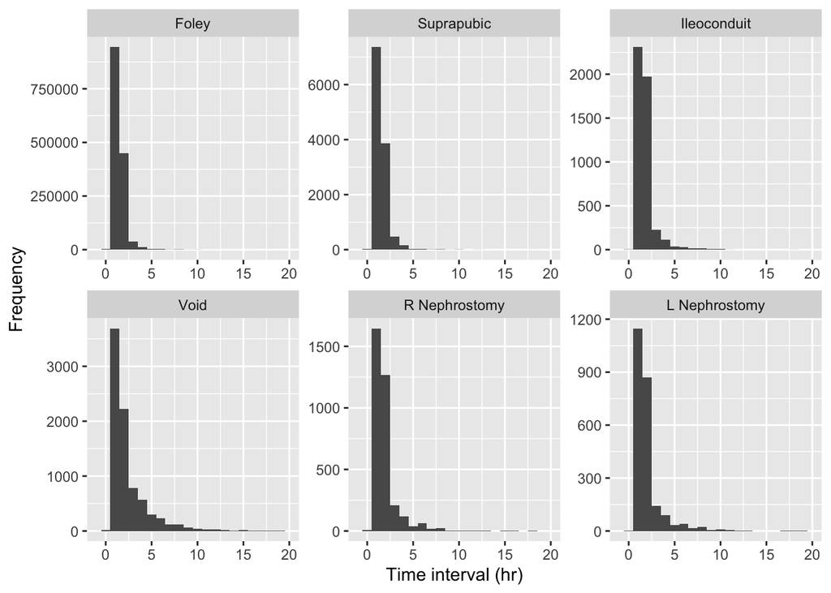

```r
bS6_b <- ggplot(data = uo_rate, aes(x = TIME_INTERVAL / 60)) +
  geom_histogram(binwidth = 1) +
  facet_wrap(~factor(SOURCE, levels=c('Foley', 'Suprapubic', 'Ileoconduit',
                         'Void',
                         'R Nephrostomy', 'L Nephrostomy')), scales = "free") +
  xlim(-1, 20) +
  labs(
          x = "Time interval (hr)",
          y = "Frequency"
        ) +
        theme(
          plot.title = element_text(color = "#0099F8", size = 16, face = "bold"),
          plot.subtitle = element_text(size = 10, face = "bold"),
          plot.caption = element_text(face = "italic")
        )

bS6_b
```

## Volumes and Collection Periods

```r
bS7_a <- uo_rate %>% group_by(SOURCE) %>%
  dplyr::summarise(N = n(),
                   Mean = round(mean(VALUE),0),
                   SD = round(sd(VALUE),0),
                   '5th' = round(quantile(VALUE, 0.05),0),
                   '10th' = round(quantile(VALUE, 0.1),0),
                   '25th' = round(quantile(VALUE, 0.25),0),
                   '50th' = round(quantile(VALUE, 0.50),0),
                   '75th' = round(quantile(VALUE, 0.75),0),
                   '95th' = round(quantile(VALUE, 0.95),0),
                   Min = round(min(VALUE),0),
                   Max = round(max(VALUE),0)
  ) %>%
  arrange(desc(N)) %>%
  gt() %>%
  fmt_number(use_seps = TRUE, decimals = 0)

bS7_a
```

| SOURCE | N | Mean | SD | 5th | 10th | 25th | 50th | 75th | 95th | Min | Max |
| --- | --- | --- | --- | --- | --- | --- | --- | --- | --- | --- | --- |
| Foley | 1,458,673 | 131 | 113 | 20 | 30 | 55 | 100 | 170 | 360 | 0 | 4,450 |
| Suprapubic | 11,994 | 124 | 118 | 10 | 20 | 50 | 90 | 160 | 370 | 0 | 2,000 |
| Void | 8,284 | 213 | 179 | 20 | 45 | 90 | 160 | 300 | 550 | 0 | 1,600 |
| Ileoconduit | 4,749 | 130 | 114 | 20 | 30 | 60 | 100 | 160 | 350 | 0 | 1,400 |
| R Nephrostomy | 3,423 | 65 | 85 | 0 | 0 | 15 | 40 | 85 | 200 | 0 | 1,200 |
| L Nephrostomy | 2,404 | 73 | 92 | 0 | 1 | 15 | 40 | 100 | 260 | 0 | 900 |

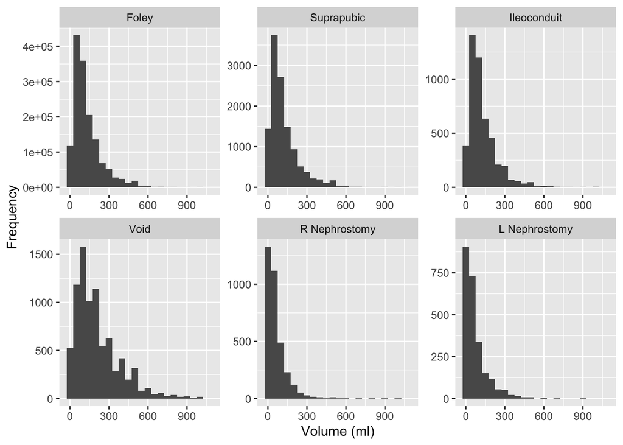

```r
bS7_b <- ggplot(data = uo_rate, aes(x = VALUE)) +
  facet_wrap(~factor(SOURCE, levels=c('Foley', 'Suprapubic', 'Ileoconduit',
                         'Void',
                         'R Nephrostomy', 'L Nephrostomy')), scales = "free") +  geom_histogram(binwidth = 50) +
  xlim(-25, 1100) +
  labs(
        # title = "Volumes",
        x = "Volume (ml)",
        y = "Frequency"
      ) +
      theme(
        plot.title = element_text(color = "#0099F8", size = 16, face = "bold"),
        plot.subtitle = element_text(size = 10, face = "bold"),
        plot.caption = element_text(face = "italic")
      )

bS7_b
```

### Records of zero volume

**The proportion of zero value UO measurements:**

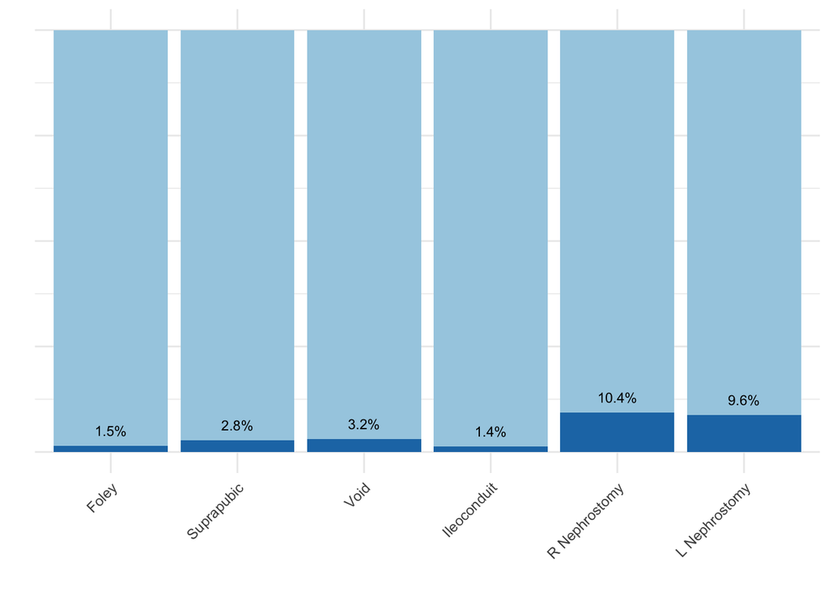

```r
uo_rate_count <- uo_rate %>%
  count(SOURCE, sort = TRUE)

uo_rate_0_count <- uo_rate %>%
  filter(VALUE == 0) %>%
  count(SOURCE, sort = TRUE)

count_uo_zero_vs_all <- left_join(uo_rate_count,
                                  uo_rate_0_count, by = "SOURCE") %>%
  mutate(PROPORTION = n.y / n.x) %>%
  pivot_longer(cols = n.y:n.x, names_to = "type")

bS7_c <- count_uo_zero_vs_all %>%
  ggplot(aes(x=reorder(SOURCE, -value), y=value, fill=type)) +
    geom_bar(position="fill", stat="identity") +
    xlab("") +
    ylab("") +
    scale_fill_brewer(palette="Paired") +
    geom_text(aes(label=ifelse(type == "n.y", paste0((round(PROPORTION, 3) * 100), "%"), "")),
          color="black",
          size=3,
          vjust=-1,
          position="fill") +
    theme_minimal() +
    theme(axis.text.y=element_blank()) +
    theme(legend.position="none") +
  theme(axis.text.y=element_blank()) +
  theme(axis.text.x = element_text(angle = 45, hjust = 1))+
     labs(
         # title = "Proportion of zero value raw output count",
       ) +
       theme(
         plot.title = element_text(color = "#0099F8", size = 16, face = "bold"),
         plot.subtitle = element_text(size = 10, face = "bold"),
         plot.caption = element_text(face = "italic")
       )
bS7_c
```

```r
uo_rate_0 <- uo_rate %>% filter(VALUE == 0)
bS7_d <- uo_rate_0 %>% group_by(SOURCE) %>%
  dplyr::summarise(N = n(),
                   Mean = round(mean(TIME_INTERVAL),0),
                   SD = round(sd(TIME_INTERVAL),0),
                   '5th' = round(quantile(TIME_INTERVAL, 0.05),0),
                   '10th' = round(quantile(TIME_INTERVAL, 0.1),0),
                   '25th' = round(quantile(TIME_INTERVAL, 0.25),0),
                   '50th' = round(quantile(TIME_INTERVAL, 0.50),0),
                   '75th' = round(quantile(TIME_INTERVAL, 0.75),0),
                   '95th' = round(quantile(TIME_INTERVAL, 0.95),0),
                   Min = round(min(TIME_INTERVAL),0),
                   Max = round(max(TIME_INTERVAL),0)
  ) %>%
  arrange(desc(N)) %>%
  gt() %>%
  fmt_number(use_seps = TRUE, decimals = 0)

bS7_d
```

| SOURCE | N | Mean | SD | 5th | 10th | 25th | 50th | 75th | 95th | Min | Max |
| --- | --- | --- | --- | --- | --- | --- | --- | --- | --- | --- | --- |
| Foley | 22,280 | 114 | 245 | 60 | 60 | 60 | 60 | 120 | 300 | 1 | 20,868 |
| R Nephrostomy | 355 | 163 | 527 | 60 | 60 | 60 | 120 | 120 | 360 | 1 | 9,720 |
| Suprapubic | 337 | 106 | 87 | 60 | 60 | 60 | 60 | 120 | 240 | 1 | 600 |
| Void | 265 | 257 | 475 | 60 | 60 | 60 | 120 | 240 | 996 | 1 | 4,560 |
| L Nephrostomy | 231 | 184 | 373 | 60 | 60 | 60 | 120 | 120 | 540 | 59 | 5,040 |
| Ileoconduit | 65 | 587 | 3,425 | 60 | 60 | 60 | 60 | 120 | 456 | 1 | 27,480 |

# Adjusting for hourly UO

## UO Rate

```r
bS8_a <- uo_rate %>% group_by(SOURCE) %>%
    dplyr::summarise(N = n(),
                   Mean = round(mean(HOURLY_RATE),0),
                   SD = round(sd(HOURLY_RATE),0),
                   '5th' = round(quantile(HOURLY_RATE, 0.05),0),
                   '10th' = round(quantile(HOURLY_RATE, 0.1),0),
                   '25th' = round(quantile(HOURLY_RATE, 0.25),0),
                   '50th' = round(quantile(HOURLY_RATE, 0.50),0),
                   '75th' = round(quantile(HOURLY_RATE, 0.75),0),
                   '95th' = round(quantile(HOURLY_RATE, 0.95),0),
                   Min = round(min(HOURLY_RATE),0),
                   Max = round(max(HOURLY_RATE),0)
  ) %>%
  arrange(desc(N)) %>%
  gt() %>%
  fmt_number(use_seps = TRUE, decimals = 0)

bS8_a
```

| SOURCE | N | Mean | SD | 5th | 10th | 25th | 50th | 75th | 95th | Min | Max |
| --- | --- | --- | --- | --- | --- | --- | --- | --- | --- | --- | --- |
| Foley | 1,458,673 | 105 | 235 | 13 | 25 | 50 | 75 | 125 | 270 | 0 | 42,000 |
| Suprapubic | 11,994 | 100 | 389 | 5 | 17 | 38 | 65 | 120 | 265 | 0 | 30,000 |
| Void | 8,284 | 119 | 264 | 10 | 25 | 50 | 90 | 150 | 300 | 0 | 21,000 |
| Ileoconduit | 4,749 | 83 | 125 | 10 | 25 | 40 | 65 | 100 | 208 | 0 | 7,200 |
| R Nephrostomy | 3,423 | 43 | 82 | 0 | 0 | 9 | 30 | 60 | 125 | 0 | 3,600 |
| L Nephrostomy | 2,404 | 52 | 103 | 0 | 1 | 9 | 30 | 60 | 200 | 0 | 3,000 |

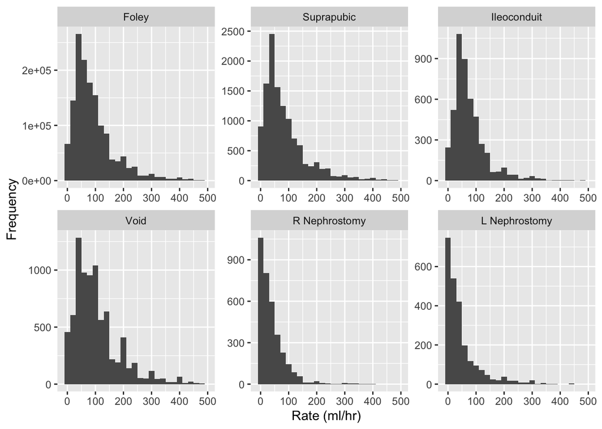

```r
bS8_b <- ggplot(data = uo_rate, aes(x = HOURLY_RATE)) +
  geom_histogram(binwidth = 20) +
  facet_wrap(~factor(SOURCE, levels=c('Foley', 'Suprapubic', 'Ileoconduit',
                         'Void',
                         'R Nephrostomy', 'L Nephrostomy')), scales = "free") +  xlim(-10, 500) +
  labs(
        # title = "UO Rates",
        # subtitle = "by source",
        x = "Rate (ml/hr)",
        y = "Frequency"
      ) +
      theme(
        plot.title = element_text(color = "#0099F8", size = 16, face = "bold"),
        plot.subtitle = element_text(size = 10, face = "bold"),
        plot.caption = element_text(face = "italic")
      )

bS8_b
```

### Low UO Rate Analysis

The association between UO rates and collection periods, smoothed conditional means for records of Foley catheter.

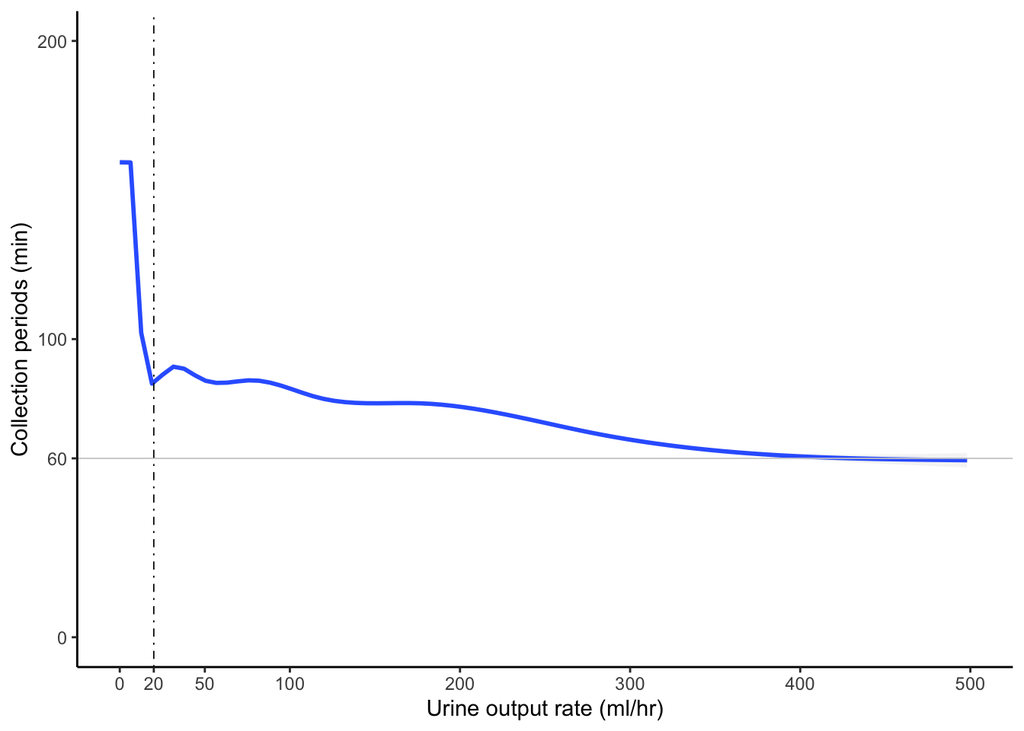

```r
bS8_d <- uo_rate %>%
  filter(SOURCE == "Foley",
         HOURLY_RATE < 500) %>%
  # slice_head(n = 50000) %>%
  ggplot(aes(x = HOURLY_RATE, y = TIME_INTERVAL)) +
  geom_smooth(se = TRUE, alpha = 0.1, linewidth = 1) +
  # geom_smooth(
  #   se = FALSE,
  #   method = "lm",
  #   linetype = "dashed",
  #   color = "red",
  #   linewidth = 0.3
  # ) +
  geom_hline(yintercept = 60,
             size = 0.3,
             color = "#cccccc") +
  geom_vline(
    xintercept = 20,
    size = 0.3,
    color = "black",
    linetype = "dotdash"
  ) +
  scale_x_continuous(breaks = c(0, 20, 50, 100, 200, 300, 400, 500)) +
  scale_y_continuous(breaks = c(0, 60, 100, 200)) +
  coord_cartesian(xlim = c(0, 500), ylim = c(0, 200)) +
  labs(x = "Urine output rate (ml/hr)", y = "Collection periods (min)") +
  theme_classic() + # remove panel background and gridlines
  theme(
    plot.title = element_text(
      color = "#0099F8",
      size = 16,
      face = "bold"
    ),
    plot.subtitle = element_text(size = 10, face = "bold"),
    plot.caption = element_text(face = "italic")
  )

bS8_d
```

Quantile analysis for collection periods as a function of rates.

```r
uo_rate_qreg <- uo_rate %>%
  filter(SOURCE == "Foley",
         HOURLY_RATE < 500) %>%
  arrange(desc(CHARTTIME)) %>%
  slice_head(n = 500000)

# #### Quantile
quantile_reg <- rq(TIME_INTERVAL ~
                     HOURLY_RATE,
                   seq(0.10, 0.90, by = 0.10),
                   # c(.05, .1, .25, .5, .75, .90, .95),
                   data = uo_rate_qreg)

# summary(quantile_reg, se = "iid") %>%
#   plot()
```

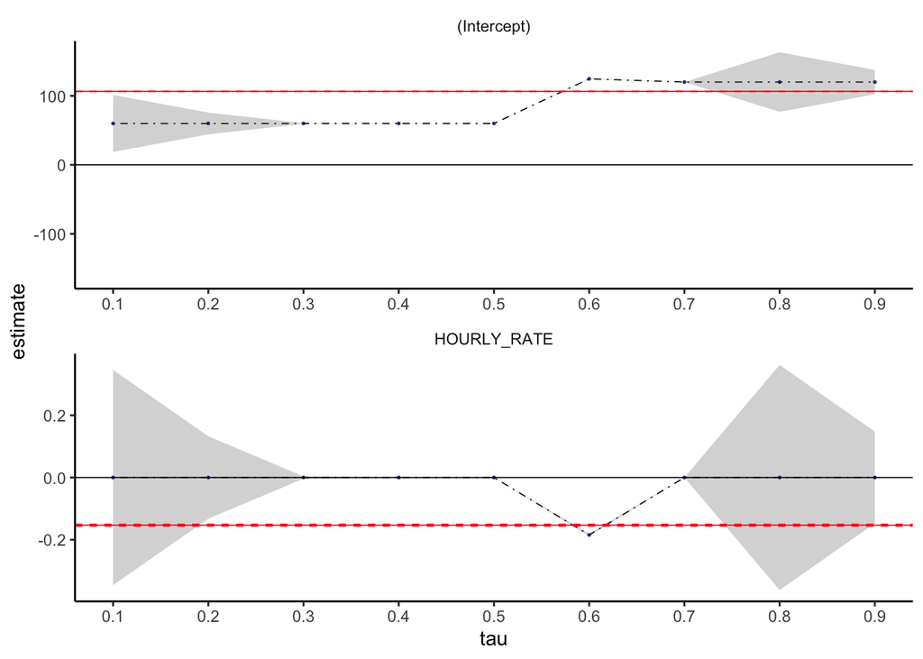

```r
### OLS
lm <- lm(data=uo_rate_qreg,
         formula =  TIME_INTERVAL ~
           HOURLY_RATE)

ols <- as.data.frame(coef(lm))
ols.ci <- as.data.frame(confint(lm, level = 0.95))
ols2 <- cbind(ols, ols.ci)
ols2 <- tibble::rownames_to_column(ols2, var="term")



#### Quantile
bS8_e <- quantile_reg %>%
  tidy(se.type = "iid", conf.int = TRUE, conf.level = 0.95) %>%
  filter(!grepl("factor", term)) %>%
  ggplot(aes(x=tau,y=estimate)) +
  theme_classic() +
  theme(
    strip.background = element_blank(),
    #strip.text.x = element_blank()
  ) +
  scale_y_continuous(limits = symmetric_limits) +
  scale_x_continuous(breaks = scales::pretty_breaks(n = 12)) +
  ##### quantilie results
  geom_point(color="#27408b", size = 0.3)+
  geom_line(color="black", linetype = "dotdash", size = 0.3)+
  geom_ribbon(aes(ymin=conf.low,ymax=conf.high),alpha=0.25, fill="#555555")+
  facet_wrap(~term, scales="free", ncol=1)+
  ##### OLS results
  geom_hline(data = ols2, aes(yintercept= `coef(lm)`), lty=1, color="red", size=0.3)+
  geom_hline(data = ols2, aes(yintercept= `2.5 %`), lty=2, color="red", size=0.3)+
  geom_hline(data = ols2, aes(yintercept= `97.5 %`), lty=2, color="red", size=0.3)+
  #### Lines
   geom_hline(yintercept = 0, size=0.3)

bS8_e
```

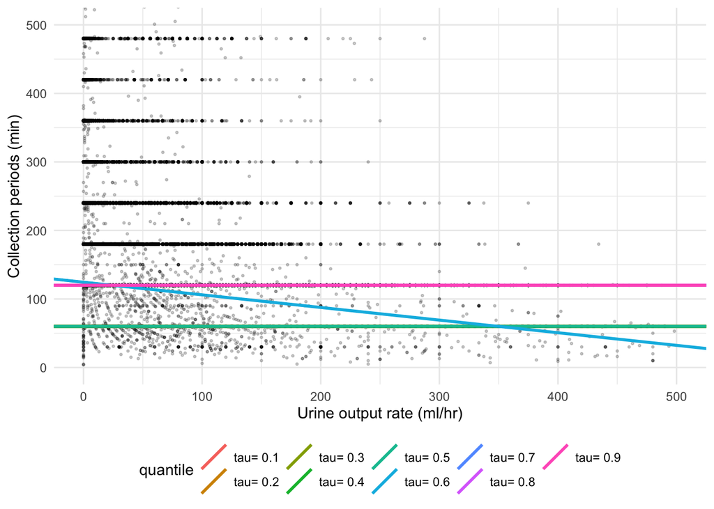

```r
# Visualization for Quantile Regression with some tau values:
intercept_slope <- quantile_reg %>%
  coef() %>%
  t() %>%
  data.frame() %>%
  rename(intercept = X.Intercept., slope = HOURLY_RATE) %>%
  mutate(quantile = row.names(.))


bS8_f <-
  ggplot() +
  geom_point(data = uo_rate_qreg, aes(HOURLY_RATE, TIME_INTERVAL),
    alpha = 0.2,
    size = 0.5,
    stroke = 0.5,
    width = 2,
    height = 2
  ) +
  geom_abline(data = intercept_slope, aes(
    intercept = intercept,
    slope = slope,
    color = quantile
  ),
  linewidth=1) +
  theme_minimal() +
  labs(x = "Urine output rate (ml/hr)", y = "Collection periods (min)") +
  coord_cartesian(xlim = c(0, 500), ylim = c(0, 500)) +
  theme(legend.position="bottom")

bS8_f
```

**Collection periods for UO rate 20ml/hr or below**

```r
uo_rate %>%
  filter(HOURLY_RATE <= 20) %>%
  group_by(SOURCE) %>%
   dplyr::summarise(N = n(),
                   Mean = round(mean(TIME_INTERVAL),0),
                   SD = round(sd(TIME_INTERVAL),0),
                   '5th' = round(quantile(TIME_INTERVAL, 0.05),0),
                   '10th' = round(quantile(TIME_INTERVAL, 0.1),0),
                   '25th' = round(quantile(TIME_INTERVAL, 0.25),0),
                   '50th' = round(quantile(TIME_INTERVAL, 0.50),0),
                   '75th' = round(quantile(TIME_INTERVAL, 0.75),0),
                   '95th' = round(quantile(TIME_INTERVAL, 0.95),0),
                   Min = round(min(TIME_INTERVAL),0),
                   Max = round(max(TIME_INTERVAL),0)
  ) %>%
  arrange(desc(N)) %>%
  gt() %>%
  fmt_number(use_seps = TRUE, decimals = 0)
```

| SOURCE | N | Mean | SD | 5th | 10th | 25th | 50th | 75th | 95th | Min | Max |
| --- | --- | --- | --- | --- | --- | --- | --- | --- | --- | --- | --- |
| Foley | 123,041 | 123 | 270 | 60 | 60 | 60 | 60 | 120 | 300 | 1 | 26,940 |
| Suprapubic | 1,588 | 113 | 88 | 60 | 60 | 60 | 116 | 120 | 240 | 1 | 1,080 |
| R Nephrostomy | 1,500 | 168 | 485 | 60 | 60 | 60 | 120 | 120 | 360 | 1 | 9,720 |
| L Nephrostomy | 1,073 | 194 | 532 | 60 | 60 | 60 | 120 | 180 | 480 | 59 | 9,720 |
| Void | 697 | 386 | 1,243 | 60 | 60 | 60 | 120 | 360 | 1,032 | 1 | 21,420 |
| Ileoconduit | 450 | 397 | 2,561 | 60 | 60 | 60 | 120 | 120 | 480 | 1 | 35,940 |

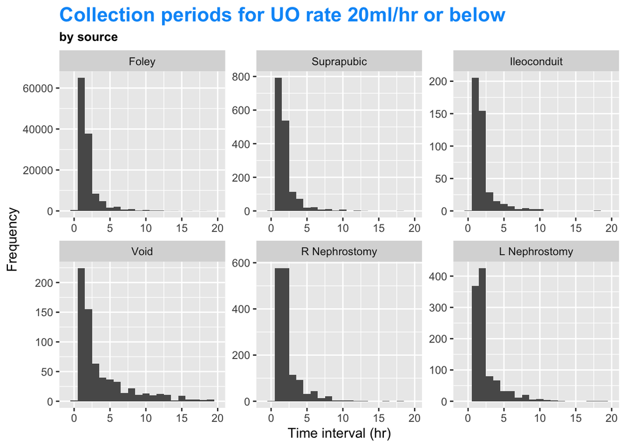

```r
uo_rate %>%
  filter(HOURLY_RATE <= 20) %>%
ggplot(aes(x = TIME_INTERVAL / 60)) +
  geom_histogram(binwidth = 1) +
  facet_wrap(~factor(SOURCE, levels=c('Foley', 'Suprapubic', 'Ileoconduit',
                         'Void',
                         'R Nephrostomy', 'L Nephrostomy')), scales = "free") +  xlim(-1, 20) +
  labs(
          title = "Collection periods for UO rate 20ml/hr or below",
          subtitle = "by source",
          x = "Time interval (hr)",
          y = "Frequency"
        ) +
        theme(
          plot.title = element_text(color = "#0099F8", size = 16, face = "bold"),
          plot.subtitle = element_text(size = 10, face = "bold"),
          plot.caption = element_text(face = "italic")
        )
```

### Mean Rate

**Mean UO rate weighted by tyme and grouped by source:**

```r
bS8_c <- uo_rate_true %>%
  group_by(SOURCE) %>%
  summarise(weighted_mean_rate = weighted.mean(HOURLY_RATE, TIME_INTERVAL)) %>%
  gt() %>%
  fmt_number(use_seps = TRUE, decimals = 1) %>%
  cols_label(
    SOURCE = "Source",
    weighted_mean_rate = "Weighted mean rate (ml/hr)"
  )

bS8_c
```

| Source | Weighted mean rate (ml/hr) |
| --- | --- |
| Foley | 94.0 |
| Ileoconduit | 76.8 |
| L Nephrostomy | 40.7 |
| R Nephrostomy | 36.5 |
| Suprapubic | 85.9 |
| Void | 89.4 |

## Hourly-adjusted UO

```r
# 2065999
bS9_a <- hourly_uo %>% drop_na(HOURLY_VALID_WEIGHTED_MEAN_RATE) %>%
    dplyr::summarise(N = n(),
                   Mean = round(mean(HOURLY_VALID_WEIGHTED_MEAN_RATE),0),
                   SD = round(sd(HOURLY_VALID_WEIGHTED_MEAN_RATE),0),
                   '5th' = round(quantile(HOURLY_VALID_WEIGHTED_MEAN_RATE, 0.05),0),
                   '10th' = round(quantile(HOURLY_VALID_WEIGHTED_MEAN_RATE, 0.1),0),
                   '25th' = round(quantile(HOURLY_VALID_WEIGHTED_MEAN_RATE, 0.25),0),
                   '50th' = round(quantile(HOURLY_VALID_WEIGHTED_MEAN_RATE, 0.50),0),
                   '75th' = round(quantile(HOURLY_VALID_WEIGHTED_MEAN_RATE, 0.75),0),
                   '95th' = round(quantile(HOURLY_VALID_WEIGHTED_MEAN_RATE, 0.95),0),
                   Min = round(min(HOURLY_VALID_WEIGHTED_MEAN_RATE),0),
                   Max = round(max(HOURLY_VALID_WEIGHTED_MEAN_RATE),0)
  ) %>%
  arrange(desc(N)) %>%
  gt() %>%
  fmt_number(use_seps = TRUE, decimals = 0)

bS9_a
```

| N | Mean | SD | 5th | 10th | 25th | 50th | 75th | 95th | Min | Max |
| --- | --- | --- | --- | --- | --- | --- | --- | --- | --- | --- |
| 2,065,999 | 94 | 79 | 12 | 25 | 45 | 74 | 120 | 240 | 0 | 3,720 |

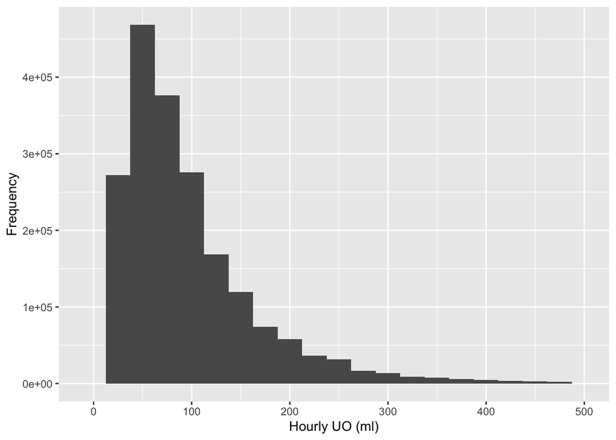

```r
bS9_b <- hourly_uo %>% drop_na(HOURLY_VALID_WEIGHTED_MEAN_RATE) %>%
ggplot(aes(x = HOURLY_VALID_WEIGHTED_MEAN_RATE)) +
  geom_histogram(binwidth = 25) +
  xlim(-10, 500) +
  labs(
        # title = "Hourly-Adjusted UO",
        x = "Hourly UO (ml)",
        y = "Frequency"
      ) +
      theme(
        plot.title = element_text(color = "#0099F8", size = 16, face = "bold"),
        plot.subtitle = element_text(size = 10, face = "bold"),
        plot.caption = element_text(face = "italic")
      )

bS9_b
```

### Simple Sum Comparison

**Showing proportion of hours with less than 100ml difference):**

```r
adj_uo_diff <- hourly_uo %>%
  select(HOURLY_VALID_WEIGHTED_MEAN_RATE, SIMPLE_SUM) %>%
  filter(!is.na(HOURLY_VALID_WEIGHTED_MEAN_RATE)) %>%
  mutate(hourly_diff = abs(HOURLY_VALID_WEIGHTED_MEAN_RATE - SIMPLE_SUM)) %>%
  mutate(
    cutoff_10 = if_else(hourly_diff < 10, 1, 0),
    cutoff_50 = if_else(hourly_diff < 50, 1, 0),
    cutoff_100 = if_else(hourly_diff < 100, 1, 0),
    cutoff_150 = if_else(hourly_diff < 150, 1, 0),
    cutoff_200 = if_else(hourly_diff < 200, 1, 0)
  )

my_order <- c("<10", "<50", "<100", "<150", "<200")

bS11 <- adj_uo_diff %>%
  select(cutoff_10,
         cutoff_50,
         cutoff_100,
         cutoff_150,
         cutoff_200) %>%
  pivot_longer(cols = contains("cutoff")) %>%
  transmute(name = case_when(
    name == "cutoff_10" ~ "<10",
    name == "cutoff_50" ~ "<50",
    name == "cutoff_100" ~ "<100",
    name == "cutoff_150" ~ "<150",
    name == "cutoff_200" ~ "<200"
  ),
  value) %>%
  group_by(name) %>%
  summarise(agreement = paste0(round(mean(value) * 100, 1), "%"),
            non_agreement = paste0(round((1 - mean(
              value
            )) * 100, 1), "%")) %>%
  arrange(match(name, my_order)) %>%
  gt() %>%
  # tab_header(
  #   title = md("**Comparison of Hourly-Adjusted UO and Simple Summation**"),
  # ) %>%
  cols_label(
    name = "Cut-off (ml)",
    agreement = "Proportion  of Agreement",
    non_agreement = "Proportion  of Disagreement"
  ) %>%
  cols_align(
    align = "center"
  ) %>%
  tab_source_note(source_note = "The table demonstrates the significance of hourly adjustment for accuracy by presenting the variance between the adjusted values and the simple hourly summation. Cut-off values are based on the absolute difference between the hourly-adjusted UO and a simple hourly summation of UO. Measurements charted on the hour were included with the previous time interval. ")

adj_uo_diff <- hourly_uo %>%
  select(HOURLY_VALID_WEIGHTED_MEAN_RATE, SIMPLE_SUM) %>%
  filter(!is.na(HOURLY_VALID_WEIGHTED_MEAN_RATE)) %>%
  mutate(no_diff =
           ifelse((is.na(HOURLY_VALID_WEIGHTED_MEAN_RATE) &
                  is.na(SIMPLE_SUM)) |
             (!is.na(HOURLY_VALID_WEIGHTED_MEAN_RATE) &
                  !is.na(SIMPLE_SUM) &
                    abs(HOURLY_VALID_WEIGHTED_MEAN_RATE-SIMPLE_SUM) < 100),
                  1,
                  0),
         .keep = "none")

bS11
```

| Cut-off (ml) | Proportion of Agreement | Proportion of Disagreement |
| --- | --- | --- |
| <10 | 27.9% | 72.1% |
| <50 | 59.1% | 40.9% |
| <100 | 81.7% | 18.3% |
| <150 | 91.8% | 8.2% |
| <200 | 96.1% | 3.9% |

The table demonstrates the significance of hourly adjustment for accuracy by presenting the variance between the adjusted values and the simple hourly summation. Cut-off values are based on the absolute difference between the hourly-adjusted UO and a simple hourly summation of UO. Measurements charted on the hour were included with the previous time interval.

```r
mean(adj_uo_diff$no_diff)
```

```
## [1] 0.8174181
```

### Hourly UO Per Kilogram

```r
# 1993167
bS9_c <- uo_ml_kg_hr %>%
  dplyr::summarise(N = n(),
                   Mean = round(mean(ML_KG_HR),2),
                   SD = round(sd(ML_KG_HR),2),
                   '5th' = round(quantile(ML_KG_HR, 0.05),2),
                   '10th' = round(quantile(ML_KG_HR, 0.1),2),
                   '25th' = round(quantile(ML_KG_HR, 0.25),2),
                   '50th' = round(quantile(ML_KG_HR, 0.50),2),
                   '75th' = round(quantile(ML_KG_HR, 0.75),2),
                   '95th' = round(quantile(ML_KG_HR, 0.95),2),
                   Min = round(min(ML_KG_HR),2),
                   Max = round(max(ML_KG_HR),2)
  ) %>% gt() %>%
  fmt_number(use_seps = TRUE, decimals = 2)

bS9_c
```

| N | Mean | SD | 5th | 10th | 25th | 50th | 75th | 95th | Min | Max |
| --- | --- | --- | --- | --- | --- | --- | --- | --- | --- | --- |
| 1,993,167.00 | 1.21 | 1.06 | 0.15 | 0.31 | 0.58 | 0.94 | 1.53 | 3.13 | 0.00 | 67.64 |

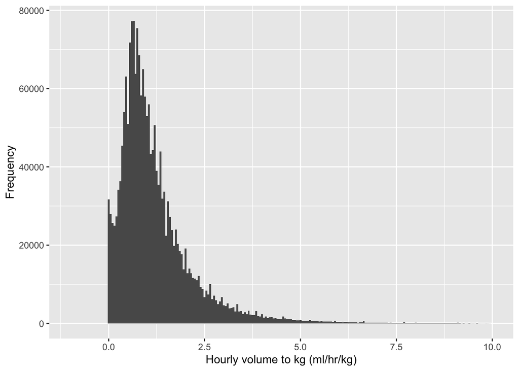

```r
mean_log <- log(mean(uo_ml_kg_hr$ML_KG_HR))
sd_log <- log(sd(uo_ml_kg_hr$ML_KG_HR))
bS9_d <- ggplot() +
  xlim(-1, 10) +
  geom_histogram(aes(x = ML_KG_HR
                     # , y =..density..
                     ), data=uo_ml_kg_hr, binwidth = 0.05) +
  # stat_function(fun = dlnorm, args = list(meanlog = mean_log, sdlog = sd_log, log = FALSE), size=1, color='gray') +
  labs(
        # title = "Hourly-Adjusted UO per Kilogram",
        x = "Hourly volume to kg (ml/hr/kg)",
        y = "Frequency"
      ) +
      theme(
        plot.title = element_text(color = "#0099F8", size = 16, face = "bold"),
        plot.subtitle = element_text(size = 10, face = "bold"),
        plot.caption = element_text(face = "italic")
      )

bS9_d
```

```r
aumc_uo_rate_true <- uo_rate_true
aumc_hourly_uo <- hourly_uo
aumc_raw_uo_eligible <- raw_uo_eligible

save(bS3a,
     bS6_a, bS6_b,
     bS7_a, bS7_b, bS7_c, bS7_d,
     bS8_a, bS8_b, bS8_c, bS8_d, bS8_e, bS8_f,
     bS9_a, bS9_b, bS9_c, bS9_d,
     bS11,
     aumc_uo_rate_true,
     aumc_hourly_uo,
     aumc_raw_uo_eligible,
     file = "bs_data.Rda")
```

# Performance analysis

describing the prevalence of oliguric-AKI upon admission and incidence at the first ICU day

```r
aki_epi %>%
  transmute(
    prevalnce_admit = first_kdigo_uo,
    Incidence_first_day = ifelse(first_kdigo_uo == 0, !is.na(max_uo_stage), NA),
    Incidence_first_day_with_stage = ifelse(first_kdigo_uo == 0 & max_uo_stage > 0, max_uo_stage, NA)
  ) %>%
  tbl_summary(
    missing = "no",
    label = list(
      prevalnce_admit ~ "Prevalence of oliguric-AKI at admission",
      Incidence_first_day ~ "Incidence of newly diagnosed AKI on the first day ",
      Incidence_first_day_with_stage ~ "Maximum KDIGO staging"
    )
  )
```

| **Characteristic** | **N = 14,884**<sup>1</sup> |
| --- | --- |
| Prevalence of oliguric-AKI at admission | 1,914 (13%) |
| Incidence of newly diagnosed AKI on the first day | 4,261 (33%) |
| Maximum KDIGO staging |  |
| 1 | 2,108 (49%) |
| 2 | 1,898 (45%) |
| 3 | 255 (6.0%) |

<sup>1</sup> n (%)

```r
akis_excluded <- aki_epi %>%
  filter(first_kdigo_uo == 0 & max_uo_stage > 0) %>%
  transmute(AKI_ID = first_aki_id) %>%
  left_join(akis, by = "AKI_ID")

akis_excluded$PEAK_UO_STAGE <- as.character(akis_excluded$PEAK_UO_STAGE)

aki_uo_analysis <- left_join(akis_excluded, uo_ml_kg_hr, by = "STAY_ID") %>%
  drop_na(AKI_START,
          TIME_INTERVAL_FINISH,
          PEAK_UO_STAGE) %>%
  select(AKI_ID,
         STAY_ID,
         PEAK_UO_STAGE,
         AKI_START,
         TIME_INTERVAL_FINISH,
         UO_KG = ML_KG_HR
         ) %>%
  mutate(TIME = as.double(difftime(TIME_INTERVAL_FINISH,
                                   AKI_START,
                                   units = c("hour")))) %>%
  filter(TIME >= -48 & TIME <= 48)
```

## First Oliguric-AKI Events

Number of identified first oliguric-AKI events in hospitalization stratified by maximum stage:

```r
akis_excluded %>%
  select(PEAK_UO_STAGE) %>%
  mutate(PEAK_UO_STAGE = as.factor(PEAK_UO_STAGE)) %>%
  tbl_summary()
```

| **Characteristic** | **N = 4,261**<sup>1</sup> |
| --- | --- |
| PEAK_UO_STAGE |  |
| 1 | 2,108 (49%) |
| 2 | 1,898 (45%) |
| 3 | 255 (6.0%) |

<sup>1</sup> n (%)

table 1 for those ICU stays, stratified by max kdigo-uo stage:

```r
akis_excluded %>%
  select(STAY_ID, PEAK_UO_STAGE) %>%
  left_join(table_1, by = "STAY_ID") %>%
  select(
    PEAK_UO_STAGE,
    admission_age,
    weight_admit,
    gender,
    creat_first,
    # scr_baseline,
    icu_days,
    rrt_binary,
    hospital_expire_flag
  ) %>%
  tbl_summary(
    by = PEAK_UO_STAGE,
    type = list(
      c(hospital_expire_flag,
        rrt_binary) ~ "dichotomous",
      c(admission_age,
        weight_admit,
        creat_first,
        # scr_baseline
        ) ~ "continuous"
    ),
    statistic = c(admission_age,
                  weight_admit,
                  creat_first,
                  # scr_baseline
                  ) ~ "{mean} ({sd})",
    missing = "no",
    missing_text = "-",
    label = list(
      admission_age ~ "Age at Hospital Admission, years",
      gender ~ "Gender",
      weight_admit ~ "Weight at ICU Admission, kg",
      creat_first ~ "First ICU Creatinine, mg/dL",
      # scr_baseline ~ "Baseline Serum Creatinine, mg/dL",
      icu_days ~ "Time in ICU, days",
      rrt_binary ~ "Renal replacement therapy",
      hospital_expire_flag ~ "Mortality"
    )
  ) %>%
  add_p()
```

| **Characteristic** | **1**, N = 2,108<sup>1</sup> | **2**, N = 1,898<sup>1</sup> | **3**, N = 255<sup>1</sup> | **p-value**<sup>2</sup> |
| --- | --- | --- | --- | --- |
| Age at Hospital Admission, years | 65 (14) | 67 (14) | 68 (14) | <0.001 |
| Weight at ICU Admission, kg | 82 (14) | 85 (15) | 81 (15) | <0.001 |
| Gender |  |  |  | 0.2 |
| F | 694 (33%) | 674 (36%) | 85 (34%) |  |
| M | 1,380 (67%) | 1,192 (64%) | 164 (66%) |  |
| First ICU Creatinine, mg/dL | 1.06 (0.50) | 1.11 (0.68) | 1.51 (1.09) | <0.001 |
| Time in ICU, days | 1 (1, 4) | 2 (1, 5) | 8 (3, 18) | <0.001 |
| Renal replacement therapy | 32 (1.5%) | 59 (3.1%) | 112 (44%) | <0.001 |
| Mortality | 140 (6.6%) | 156 (8.2%) | 94 (37%) | <0.001 |

<sup>1</sup> Mean (SD); n (%); Median (IQR)  
<sup>2</sup> Kruskal-Wallis rank sum test; Pearson’s Chi-squared test

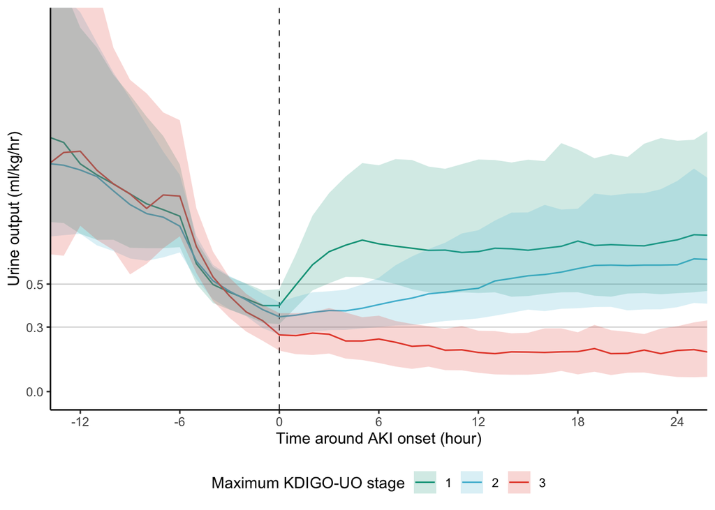

```r
aumc_uo_figure <- aki_uo_analysis %>%
 ggplot(aes(TIME, UO_KG, color=PEAK_UO_STAGE, fill=PEAK_UO_STAGE))  +
           # linetype=PEAK_UO_STAGE))  +
  geom_hline(yintercept=0.3, size = 0.3, color = "#cccccc") +
  geom_hline(yintercept=0.5, size = 0.3, color = "#cccccc") +
  geom_vline(xintercept=0, size = 0.3, color = "black", linetype = "dashed") +
  stat_summary(fun = median, geom="line") +
  scale_x_continuous(breaks = seq(-24, 48, by=6)) +
  scale_y_continuous(breaks = c(0, 0.3, 0.5)) +
  coord_cartesian(xlim = c(-12, 24), ylim = c(0, 1.7)) +
  # xlim(-24, 48) +
  stat_summary(fun.min = function(z) { quantile(z,0.25) },
               fun.max = function(z) { quantile(z,0.75) },
               geom="ribbon", colour = NA, alpha=0.2) +
  labs(x="Time around AKI onset (hour)", y = "Urine output (ml/kg/hr)",
       # title="Hourly Urine Output at the Onset of Oliguric AKI Events",
       color="Maximum KDIGO-UO stage", fill="Maximum KDIGO-UO stage") +
       # linetype="Peak AKI stage") +
  theme_classic() + # remove panel background and gridlines
  # annotate("rect", xmin = -24, xmax = 48, ymin = 0, ymax = 0.5,
  #          alpha = .1) +
  # annotate("rect", xmin = -24, xmax = 48, ymin = 0, ymax = 0.3,
  #          alpha = .1) +
  scale_colour_manual(values=c("#00a087ff", "#4dbbd5ff", "#e64b35ff")
                      # ,labels=c("1 (N=12,911)","2 (N=10,619)","3 (N=1,300)")
                      ) +
  scale_fill_manual(values=c("#00a087ff", "#4dbbd5ff", "#e64b35ff")
                    # ,labels=c("1 (N=12,911)","2 (N=10,619)","3 (N=1,300)")
                      ) +
  theme(
    legend.position = "bottom",
    plot.title = element_text(color = "#0099F8", size = 16, face = "bold"),
    plot.subtitle = element_text(size = 10, face = "bold"),
    plot.caption = element_text(face = "italic")
  )
aumc_uo_figure
```

## Survival Analysis

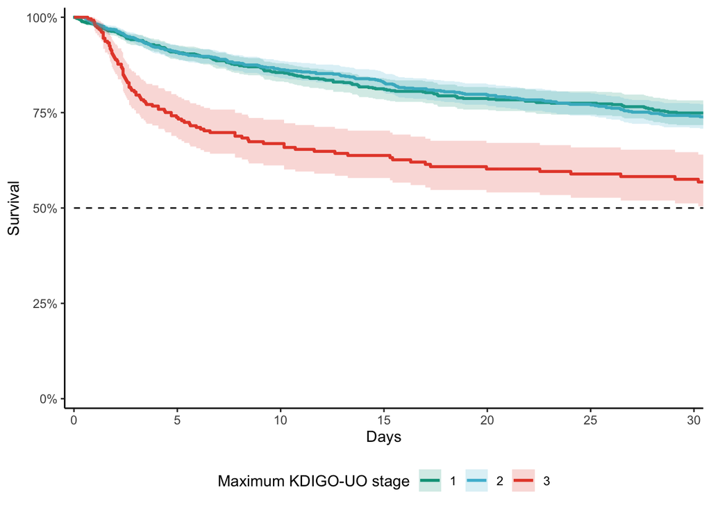

```r
km_fit <- survfit2(Surv(FIRST_AKI_TO_DEATH_OR_DISCH, HADM_DEATH_FLAG) ~ PEAK_UO_STAGE, data = akis_excluded)

aumc_survival_figure <- km_fit %>%
ggsurvfit(linewidth = 1) +
  add_confidence_interval() +
  add_quantile() +
  scale_ggsurvfit(x_scales = list(breaks = seq(0, 30, by = 5))) +
  coord_cartesian(xlim = c(0, 30)) +
  theme_classic() +
  labs(x="Days", y = "Survival",
       # title="30-Days Survival Analysis",
       # subtitle = "Stratified by first hospitalization AKI event peak staging",
       color='Maximum KDIGO-UO stage', fill='Maximum KDIGO-UO stage') +
  scale_colour_manual(values=c("#00a087ff", "#4dbbd5ff", "#e64b35ff"),
                    labels=c("1","2","3")) +
  scale_fill_manual(values=c("#00a087ff", "#4dbbd5ff", "#e64b35ff"),
                    labels=c("1","2","3")) +
  theme(legend.position = "bottom",
        plot.title = element_text(color = "#0099F8", size = 16, face = "bold"),
        plot.subtitle = element_text(size = 10, face = "bold"))
  # + add_pvalue(caption = "Log-rank {p.value}")

aumc_survival_figure
```

**table of survival probabilities:**

```r
survfit2(Surv(FIRST_AKI_TO_DEATH_OR_DISCH, HADM_DEATH_FLAG) ~ 1,
           data = akis_excluded) %>% tbl_survfit(times = c(7, 30),
                                                 label = "Maximum KDIGO-UO stage",
                                                 label_header = "**Day {time}**")
```

| **Characteristic** | **Day 7** | **Day 30** |
| --- | --- | --- |
| Maximum KDIGO-UO stage | 87% (85%, 88%) | 73% (70%, 75%) |

```r
aumc_survival_table <-
  survfit2(Surv(FIRST_AKI_TO_DEATH_OR_DISCH, HADM_DEATH_FLAG) ~ PEAK_UO_STAGE,
           data = akis_excluded) %>% tbl_survfit(times = c(7, 30),
                                                 label = "Maximum KDIGO-UO stage",
                                                 label_header = "**Day {time}**")
aumc_survival_table
```

| **Characteristic** | **Day 7** | **Day 30** |
| --- | --- | --- |
| Maximum KDIGO-UO stage |  |  |
| 1 | 89% (87%, 91%) | 75% (72%, 78%) |
| 2 | 89% (87%, 91%) | 74% (71%, 77%) |
| 3 | 70% (64%, 76%) | 58% (51%, 65%) |

**Log rank for each pair:**

```r
survdiff(Surv(FIRST_AKI_TO_DEATH_OR_DISCH, HADM_DEATH_FLAG) ~ PEAK_UO_STAGE,
         data = akis_excluded)
```

```
## Call:
## survdiff(formula = Surv(FIRST_AKI_TO_DEATH_OR_DISCH, HADM_DEATH_FLAG) ~
##     PEAK_UO_STAGE, data = akis_excluded)
##
##                    N Observed Expected (O-E)^2/E (O-E)^2/V
## PEAK_UO_STAGE=1 2108      579      629     4.045     7.653
## PEAK_UO_STAGE=2 1898      606      618     0.252     0.468
## PEAK_UO_STAGE=3  255      164      101    39.190    42.719
##
##  Chisq= 43.9  on 2 degrees of freedom, p= 3e-10
```

```r
akis_excluded_non_1 <- akis_excluded %>%
  filter(PEAK_UO_STAGE != 1)
survdiff(Surv(FIRST_AKI_TO_DEATH_OR_DISCH, HADM_DEATH_FLAG) ~ PEAK_UO_STAGE,
         data = akis_excluded_non_1)
```

```
## Call:
## survdiff(formula = Surv(FIRST_AKI_TO_DEATH_OR_DISCH, HADM_DEATH_FLAG) ~
##     PEAK_UO_STAGE, data = akis_excluded_non_1)
##
##                    N Observed Expected (O-E)^2/E (O-E)^2/V
## PEAK_UO_STAGE=2 1898      606      661      4.51      32.2
## PEAK_UO_STAGE=3  255      164      109     27.23      32.2
##
##  Chisq= 32.2  on 1 degrees of freedom, p= 1e-08
```

```r
akis_excluded_non_2 <- akis_excluded %>%
  filter(PEAK_UO_STAGE != 2)
survdiff(Surv(FIRST_AKI_TO_DEATH_OR_DISCH, HADM_DEATH_FLAG) ~ PEAK_UO_STAGE,
         data = akis_excluded_non_2)
```

```
## Call:
## survdiff(formula = Surv(FIRST_AKI_TO_DEATH_OR_DISCH, HADM_DEATH_FLAG) ~
##     PEAK_UO_STAGE, data = akis_excluded_non_2)
##
##                    N Observed Expected (O-E)^2/E (O-E)^2/V
## PEAK_UO_STAGE=1 2108      579      639      5.63      40.9
## PEAK_UO_STAGE=3  255      164      104     34.59      40.9
##
##  Chisq= 40.9  on 1 degrees of freedom, p= 2e-10
```

```r
akis_excluded_non_3 <- akis_excluded %>%
  filter(PEAK_UO_STAGE != 3)
survdiff(Surv(FIRST_AKI_TO_DEATH_OR_DISCH, HADM_DEATH_FLAG) ~ PEAK_UO_STAGE,
         data = akis_excluded_non_3)
```

```
## Call:
## survdiff(formula = Surv(FIRST_AKI_TO_DEATH_OR_DISCH, HADM_DEATH_FLAG) ~
##     PEAK_UO_STAGE, data = akis_excluded_non_3)
##
##                    N Observed Expected (O-E)^2/E (O-E)^2/V
## PEAK_UO_STAGE=1 2108      579      599     0.689      1.41
## PEAK_UO_STAGE=2 1898      606      586     0.705      1.41
##
##  Chisq= 1.4  on 1 degrees of freedom, p= 0.2
```

```r
aumc_aki_epi <- aki_epi
aumc_akis <- akis
aumc_t1a <- t1a
aumc_t1b <- t1b
aumc_table_1 <- table_1
aumc_uo_rate <- uo_rate

save(aumc_aki_epi,
     aumc_akis,
     aumc_t1a,
     aumc_t1b,
     aumc_table_1,
     aumc_uo_rate,
     aumc_uo_figure,
     aumc_survival_figure,
     aumc_survival_table,
     file = "paper_aumc.Rda")
```